# First-line pembrolizumab versus platinum-based chemotherapy for metastatic NSCLC with PD-L1 TPS ≥ 50%

A partitioned survival cost-effectiveness model based on KEYNOTE-024 (five-year analysis), structured after NICE TA531

Author

Salvatore Barbagallo

Published

October 23, 2026

**Note**

This is an independent model built from public sources. It is **not** the model submitted to NICE and its results are **not** NICE’s results. The appraisal’s decision-making ICERs include confidential discounts that are not public. This model uses list prices throughout.

# 1 Decision problem

| Element | Specification |
| --- | --- |
| Population | Adults with untreated metastatic non-small-cell lung cancer (NSCLC), PD-L1 tumour proportion score ≥ 50%, no EGFR or ALK aberrations (KEYNOTE-024 population) |
| Intervention | Pembrolizumab 200 mg every 3 weeks until progression, to a maximum of 35 administrations (2 years) |
| Comparator | Platinum-based chemotherapy as given in KEYNOTE-024 (carboplatin or cisplatin with pemetrexed, gemcitabine or paclitaxel; optional pemetrexed maintenance) |
| Outcomes | Life years, quality-adjusted life years (QALYs), costs |
| Perspective | NHS and Personal Social Services (England) |
| Time horizon | 20 years (1,044 weekly cycles) |
| Discounting | 3.5% per year for costs and QALYs, at cycle midpoints |
| Half-cycle correction | Trapezoidal (life-table) method: occupancy in each cycle is the mean of state membership at its start and end |
| Prices | List prices (2024/25 unit costs; eMIT 2025/26 for generic drugs) |

The structure mirrors the company model accepted in NICE technology appraisal TA531: a three-state partitioned survival model with weekly cycles, a 20-year horizon, a 2-year (35-cycle) stopping rule for pembrolizumab, and utilities based on time to death. Clinical inputs come from the five-year KEYNOTE-024 analysis (Reck et al. 2021; data cut-off 1 June 2020; median follow-up 59.9 months), not the July 2017 data used in the appraisal.

# 2 Methods

## 2.1 Individual patient data

Kaplan–Meier (KM) curves for overall survival (OS, Figure 2A) and progression-free survival (PFS, Figure 2B) of Reck et al. (2021) were extracted from the vector artwork in the article PDF (PMC Open Access copy). Each arm’s step path was read directly, with axes calibrated on the drawn tick marks. The numbers at risk were taken from the PDF’s text layer. Individual patient data (IPD) were reconstructed with the Guyot et al. (2012) algorithm (`IPDfromKM::getIPD`), with the randomised numbers (154 and 151) and the event totals reported for the same data cut.

Acceptance thresholds were set before reconstruction: medians within 1 month, hazard ratios within 0.03, and landmark survival within 3 percentage points where the paper reports it.

## 2.2 Survival extrapolation

Following NICE DSU TSD 14 and TSD 21, nine models were fitted separately to each arm and endpoint: exponential, Weibull, Gompertz, log-logistic, lognormal, generalised gamma, and Royston–Parmar splines on the hazard scale with one to three internal knots. Selection considered AIC and BIC, visual fit, smoothed hazards, log-cumulative-hazard plots, and the plausibility of extrapolated survival at 5, 10 and 20 years.

Two constraints apply in every cycle:

- the OS hazard is never below general-population mortality for a cohort aged 65 with 64.6% male (the TA531 company model’s baseline), from the ONS National Life Tables for England, 2022–2024;
- PFS never exceeds OS.

## 2.3 Treatment duration

KEYNOTE-024 time-on-treatment curves are not public. Time on pembrolizumab is therefore **assumed** equal to PFS, capped at 35 doses. Chemotherapy is given for up to 6 three-weekly cycles while progression-free, which gives a modelled mean of 5.04 cycles (the mean observed in KEYNOTE-024 was 5.05). The modelled mean number of pembrolizumab administrations is 17.5. 30.5% of the chemotherapy arm (46 of 151) continue on pemetrexed maintenance while progression-free.

## 2.4 Health-related quality of life

Utilities come from KEYNOTE-024 EQ-5D-3L data as reported in the TA531 committee papers, pooled across arms and grouped by time to death: 0.808 (≥360 days), 0.712 (180–360), 0.598 (30–180) and 0.480 (<30 days). For people alive in each cycle, the probability of being in each band is derived from that arm’s OS curve. The ≥360-day value is capped at the general-population EQ-5D norm for the cohort’s age and sex, as the committee preferred. All utilities are age-adjusted multiplicatively using the NICE DSU (2022) EQ-5D-3L norms. Progression-based utilities (0.778 and 0.668) are a scenario.

## 2.5 Costs

All costs are in 2024/25 prices, at list price.

| Item | Value | Source |
| --- | --- | --- |
| Pembrolizumab, per administration (acquisition) | £5,218.45 | dm+d/BNF list price £2,630 per 100 mg; dose intensity 99.21% |
| Administration, simple outpatient (SB12Z) | £256.03 | National Cost Collection 2024/25 |
| Chemotherapy per cycle (drug + administration, KEYNOTE-024 mix) | £860.21 | eMIT 2025/26; NCC 2024/25; TA531 regimen mix |
| Pemetrexed maintenance, per administration | £599.41 | eMIT 2025/26; NCC 2024/25 |
| Monitoring, progression-free (per week) | £99.40 | TA531 resource use, uprated with the NHS Cost Inflation Index |
| Monitoring, progressed (per week) | £163.01 | As above |
| Terminal care (one-off at death) | £6,133.16 | As above |
| Adverse events (one-off), pembrolizumab / chemotherapy | £514.60 / £1,797.56 | TA531 AE rates and unit costs, uprated |
| Subsequent anti-PD-(L)1 course | £47,627.94 | 26.1 weeks of pembrolizumab |

Subsequent therapy follows the use reported in KEYNOTE-024 (Reck 2021, Appendix Table A1). In the chemotherapy arm, 65.6% received anti-PD-(L)1 therapy (66.0% effective crossover), so costs stay consistent with the trial survival. These costs are applied at each PFS event.

# 3 Survival analysis

## 3.1 Reconstruction

Reconstructed IPD against published KEYNOTE-024 results (survival in %).

| Endpoint | Check | Published | Reconstructed | Result |
| --- | --- | --- | --- | --- |
| OS | Median (pembro), months | 26.30 | 26.35 | pass |
| OS | Median (chemo), months | 13.40 | 13.44 | pass |
| OS | HR pembro vs chemo (unstratified Cox) | 0.62 | 0.64 | pass |
| OS | Total events (pembro) | 103 | 106 | report only |
| OS | Total events (chemo) | 123 | 124 | report only |
| OS | 1-year survival (pembro) | – | 70.3 | report only |
| OS | 2-year survival (pembro) | – | 51.8 | report only |
| OS | 5-year survival (pembro) | 31.9 | 31.6 | pass |
| OS | 1-year survival (chemo) | – | 54.0 | report only |
| OS | 2-year survival (chemo) | – | 33.9 | report only |
| OS | 5-year survival (chemo) | 16.3 | 16.4 | pass |
| PFS | Median (pembro), months | 7.70 | 7.65 | pass |
| PFS | Median (chemo), months | 5.50 | 5.49 | pass |
| PFS | HR pembro vs chemo (unstratified Cox) | 0.50 | 0.50 | pass |
| PFS | Total events (pembro) | 126 | 128 | report only |
| PFS | Total events (chemo) | 141 | 142 | report only |
| PFS | 1-year survival (pembro) | – | 41.5 | report only |
| PFS | 2-year survival (pembro) | – | 27.6 | report only |
| PFS | 3-year survival (pembro) | 22.8 | 22.5 | pass |
| PFS | 5-year survival (pembro) | 12.8 | 12.5 | pass |
| PFS | 1-year survival (chemo) | – | 13.9 | report only |
| PFS | 2-year survival (chemo) | – | 6.4 | report only |
| PFS | 3-year survival (chemo) | 4.1 | 3.8 | pass |
| PFS | 5-year survival (chemo) | – | – | report only |

Every pre-specified check passed. The published hazard ratios come from Cox models stratified by ECOG performance status, histology and region. The reconstructed hazard ratios are unstratified, because the reconstructed data carry no stratification factors.

## 3.2 Model selection

OS models by arm: fit statistics and extrapolated survival with the general-population floor.

| Arm | Model | ΔAIC | ΔBIC | 5 years | 10 years | 20 years |
| --- | --- | --- | --- | --- | --- | --- |
| Chemotherapy | Lognormal | 0.0 | 0.0 | 16.0% | 7.2% | 2.7% |
| Chemotherapy | Generalised gamma | 1.9 | 5.0 | 16.3% | 7.6% | 3.0% |
| Chemotherapy | Log-logistic | 2.4 | 2.4 | 15.6% | 7.7% | 3.6% |
| Chemotherapy | RP spline (1 knot) | 3.3 | 6.3 | 16.1% | 6.5% | 1.7% |
| Chemotherapy | Gompertz | 4.1 | 4.1 | 15.9% | 10.3% | 6.4% |
| Chemotherapy | RP spline (2 knots) | 5.2 | 11.3 | 16.1% | 6.4% | 1.6% |
| Chemotherapy | RP spline (3 knots) | 7.1 | 16.1 | 16.1% | 6.7% | 1.8% |
| Chemotherapy | Weibull | 11.4 | 11.4 | 13.7% | 3.1% | 0.2% |
| Chemotherapy | Exponential | 19.4 | 16.4 | 10.6% | 1.1% | 0.0% |
| Pembrolizumab | Log-logistic | 0.0 | 0.0 | 30.5% | 17.8% | 9.1% |
| Pembrolizumab | Lognormal | 0.8 | 0.8 | 31.5% | 18.8% | 9.5% |
| Pembrolizumab | Gompertz | 1.1 | 1.1 | 30.1% | 19.9% | 12.2% |
| Pembrolizumab | RP spline (1 knot) | 1.2 | 4.2 | 30.4% | 15.1% | 5.0% |
| Pembrolizumab | Generalised gamma | 1.5 | 4.5 | 30.4% | 16.0% | 6.6% |
| Pembrolizumab | Weibull | 2.3 | 2.3 | 29.4% | 12.0% | 2.5% |
| Pembrolizumab | RP spline (2 knots) | 3.2 | 9.2 | 30.4% | 15.0% | 4.9% |
| Pembrolizumab | RP spline (3 knots) | 5.0 | 14.1 | 30.4% | 14.3% | 4.1% |
| Pembrolizumab | Exponential | 8.5 | 5.4 | 26.8% | 7.2% | 0.5% |

The proportional-hazards test on the treatment term gives p = 0.66 for OS and p = 0.001 for PFS, where the curves cross in the first months. Models were fitted separately to each arm.

**Base case: lognormal for OS and PFS in both arms.** For OS it has the lowest combined AIC across arms and the lowest BIC in the chemotherapy arm. It reproduces the observed 5-year OS (31.5% vs a reconstructed KM of 31.6% for pembrolizumab; 16.0% vs 16.4% for chemotherapy). The generalised gamma shape parameter Q includes 0 in its 95% confidence interval for 4 of 4 curves (OS pembrolizumab: 0.39, 95% CI -0.27 to 1.05), so the lognormal is not rejected against its more flexible parent. Gompertz flattens into an implausible plateau. Weibull and exponential fit poorly. Using the same family in both arms follows TSD 14.

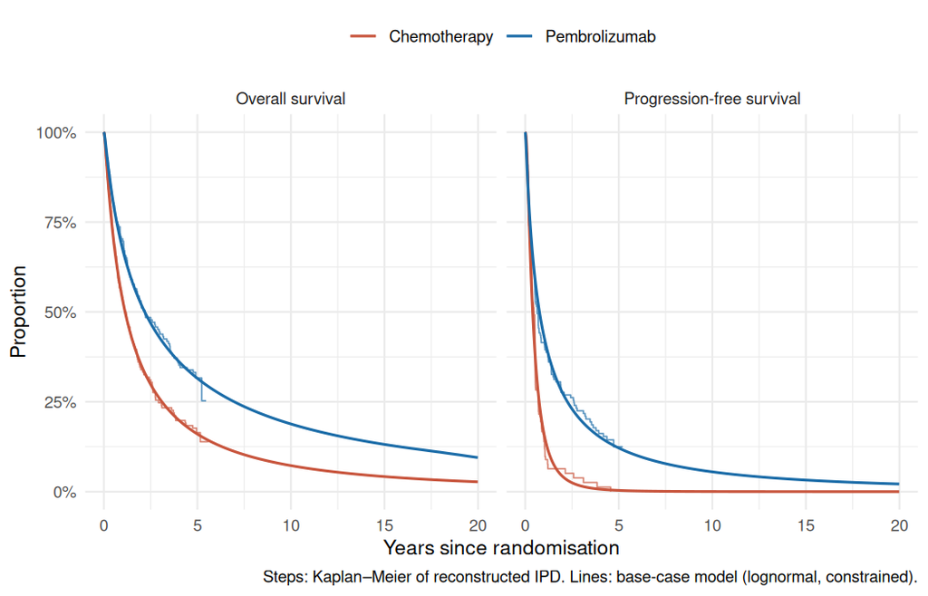

Base-case modelled survival against the reconstructed Kaplan–Meier data.

# 4 Results

## 4.1 Base case

Base-case results (discounted unless stated, list prices).

| Outcome | Pembrolizumab | Chemotherapy | Incremental |
| --- | --- | --- | --- |
| Total costs | £135,281 | £63,499 | £71,782 |
| Life years (discounted) | 4.20 | 2.45 | 1.75 |
| Life years (undiscounted) | 5.16 | 2.85 | 2.32 |
| QALYs | 3.20 | 1.83 | 1.36 |

At list prices, pembrolizumab costs £71,782 more than chemotherapy and gives 1.36 more QALYs. The ICER is **£52,670 per QALY gained**. Net monetary benefit is −£44,525 at £20,000 per QALY and −£30,896 at £30,000 per QALY.

Discounted costs by category.

| Category | Pembrolizumab | Chemotherapy | Difference |
| --- | --- | --- | --- |
| Monitoring, progression-free | £10,193 | £3,100 | £7,093 |
| Monitoring, progressed | £19,009 | £15,783 | £3,226 |
| First-line drug acquisition | £88,908 | £1,492 | £87,417 |
| First-line administration | £4,362 | £2,822 | £1,540 |
| Pemetrexed maintenance | £0 | £1,930 | −£1,930 |
| Adverse events | £514 | £1,797 | −£1,283 |
| Subsequent therapy | £7,339 | £31,043 | −£23,705 |
| Terminal care | £4,955 | £5,531 | −£576 |

## 4.2 One-way sensitivity analysis

Each varying input was set to the 2.5th and 97.5th percentiles of its PSA distribution. The ICER ranged from £49,984 to £55,624. The two most influential inputs were: subsequent-therapy use, chemotherapy arm (each therapy at its 2.5th/97.5th beta percentile); and monitoring and disease management, progression-free.

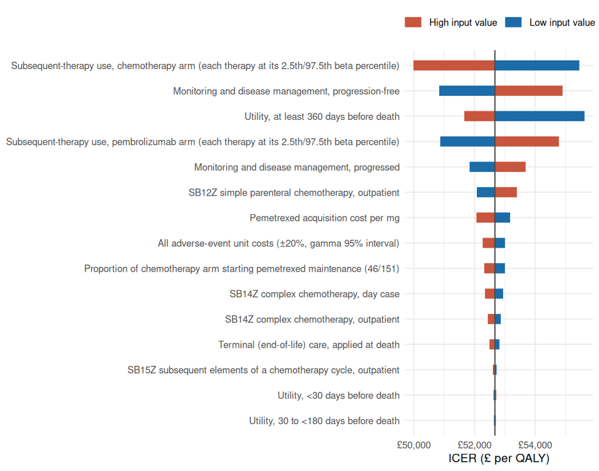

Tornado diagram (15 most influential inputs).

## 4.3 Probabilistic sensitivity analysis

1,000 iterations with a fixed seed (531). Survival parameters were drawn from multivariate normal distributions using each fit’s variance–covariance matrix, utilities and proportions from beta distributions, and costs from gamma distributions. The probabilistic ICER (ratio of mean costs to mean QALYs) is £53,477 per QALY, against a deterministic £52,670. The probability that pembrolizumab is cost-effective at list price is 0.0% at £20,000 and 0.1% at £30,000 per QALY.

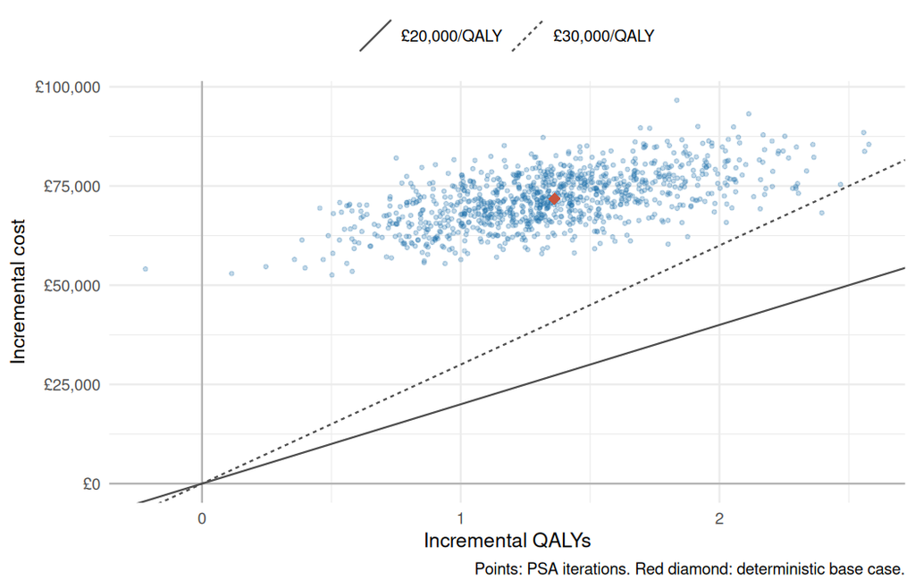

Cost-effectiveness plane.

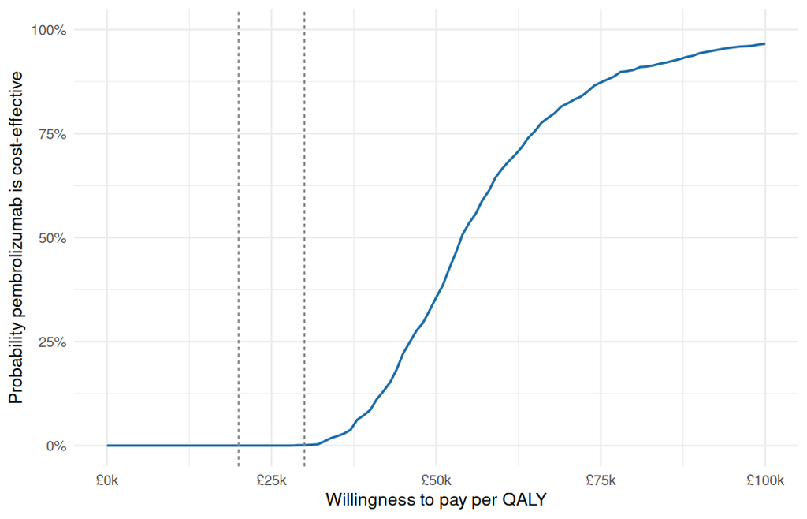

Cost-effectiveness acceptability curve.

## 4.4 Price threshold analysis

Because the confidential discounts are not public, the analysis asks what price reduction would be needed. A discount on every pembrolizumab administration (including subsequent anti-PD-(L)1 therapy in the chemotherapy arm, costed as pembrolizumab) of **68.3%** gives an ICER of £20,000 per QALY, and **47.4%** gives £30,000 per QALY.

# 5 Scenario analyses

Scenario analyses (base-case ICER £52,670).

| Group | Scenario | Incremental cost | Incremental QALYs | ICER |
| --- | --- | --- | --- | --- |
| KM cut-off | OS: KM to 23 weeks + exponential (TA531) | £68,673 | 1.05 | £65,646 |
| KM cut-off | OS: KM to 33 weeks + exponential (TA531) | £68,715 | 1.05 | £65,237 |
| KM cut-off | OS: KM to 43 weeks + exponential (TA531) | £68,349 | 1.02 | £67,164 |
| Distribution | OS distribution: Log-logistic | £70,969 | 1.28 | £55,282 |
| Distribution | OS distribution: Generalised gamma | £69,507 | 1.14 | £60,852 |
| Distribution | OS distribution: RP spline (1 knot) | £69,588 | 1.15 | £60,550 |
| Distribution | OS distribution: Gompertz | £70,764 | 1.26 | £56,022 |
| Distribution | OS distribution: Weibull | £69,566 | 1.14 | £60,841 |
| Distribution | OS distribution: Exponential | £68,400 | 1.01 | £67,762 |
| Distribution | PFS distribution: Log-logistic | £70,052 | 1.36 | £51,401 |
| Distribution | PFS distribution: RP spline (1 knot) | £69,172 | 1.36 | £50,755 |
| Waning | Waning: HR = 1 from 3 years | £66,417 | 0.85 | £78,365 |
| Waning | Waning: HR = 1 from 5 years | £68,578 | 1.05 | £65,081 |
| Stopping rule | No 2-year stopping rule (treat to progression) | £168,298 | 1.36 | £123,489 |
| Utilities | Progression-based utilities | £71,782 | 1.27 | £56,544 |
| Utilities | Time-to-death utilities, 360+ days not capped at norm | £71,782 | 1.36 | £52,670 |
| Discounting | Discount rate 1.5% (costs and QALYs) | £75,091 | 1.59 | £47,370 |

Capping the ≥360-day utility at the population norm has no effect, because the KEYNOTE-024 value (0.808) is already below the DSU 2022 norm for the cohort at age 65 (0.824).

# 6 Validation against TA531

Mean undiscounted survival: this model against the TA531 company model (§3.18).

| Analysis | Pembrolizumab (months) | Chemotherapy (months) |
| --- | --- | --- |
| TA531 company model (TA531 §3.18, July 2017 data) | 36.0 | 22.3 |
| This model, base case (lognormal, 2020 data) | 62.0 | 34.2 |
| This model, TA531-like extrapolation (KM to 33 weeks + exponential, 2020 data) | 47.6 | 27.7 |

The modelled mean survival is longer than in TA531 in both arms. The main reasons:

| Difference | TA531 company model | This model | Expected effect |
| --- | --- | --- | --- |
| Data cut | July 2017 (median follow-up 25.2 months) | 1 June 2020 (median follow-up 59.9 months) | Long-term survival observed for 5 years rather than extrapolated from about 2; raises mean OS in both arms |
| OS extrapolation | KM to 33 weeks, then exponential | Lognormal fitted to all data | The exponential’s constant hazard cannot follow the falling hazard seen in the five-year data. Applied to the 2020 data, the TA531 method gives 47.6 and 27.7 months |
| Crossover in the comparator arm | 43.7% crossed over at the 2017 cut (committee papers) | 66.0% effective crossover | Longer chemotherapy-arm survival; neither model adjusts for crossover (TA531 §3.5) |
| Prices | Confidential discounts (pembrolizumab, pemetrexed) | List prices; generic pemetrexed from eMIT | Affects costs, not survival; list prices raise the ICER |
| Time on treatment | Parametric curves fitted to KEYNOTE-024 time-on-treatment data | PFS capped at 2 years (assumption) | Affects pembrolizumab drug costs, not survival |
| Utilities | Time to death; committee preferred the ≥360-day value at the population norm | Same approach, DSU 2022 norms, age-adjusted | Small effect on QALYs |

The base-case ICER here, £52,670 per QALY, is above the committee’s range of £30,000 to under £50,000 per QALY, which included the confidential discounts. The threshold analysis shows the size of discount that would bring this model’s ICER into that range.

# 7 Limitations

- **Reconstructed data.** All survival inputs come from IPD reconstructed from published KM curves, not from the trial data. The reconstruction matches the published medians, hazard ratios and landmarks closely, but covariates, stratification factors and exact censoring times are lost.
- **List prices.** The NHS pays confidential, discounted prices for pembrolizumab. The ICERs here are therefore not those that informed NICE’s decision. The threshold analysis gives the discount needed instead.
- **Time on treatment.** KEYNOTE-024 time-on-treatment curves are not public. Treatment duration is assumed equal to PFS, capped at 2 years. Patients who stop early for toxicity, or continue beyond progression, are not represented. Pembrolizumab acquisition is the largest cost, so this assumption matters.
- **Immature, crossover-affected comparator tail.** In the chemotherapy arm, 66.0% of patients received anti-PD-(L)1 therapy and few remain at risk after 5 years (3 at 66 months). The chemotherapy OS tail reflects a mixed treatment pathway, and its extrapolation rests on very few patients.
- **Inputs from the 2017 appraisal.** Utilities, adverse-event rates, resource use and the regimen mix come from the TA531 submission (KEYNOTE-024 2016 data cut). Monitoring, terminal-care and AE costs are 2014/15 values uprated with a price index rather than re-costed item by item.
- **Subsequent therapy** is costed for immunotherapy, platinum doublets and single-agent chemotherapy only. Radiotherapy, surgery and targeted therapies reported in the trial are not costed.

# 8 Sources

- Reck M, Rodríguez-Abreu D, Robinson AG, et al. Five-year outcomes with pembrolizumab versus chemotherapy for metastatic non–small-cell lung cancer with PD-L1 tumor proportion score ≥ 50%. *J Clin Oncol* 2021;39(21):2339–2349. doi:10.1200/JCO.21.00174 (CC BY-NC-ND 4.0).
- NICE. Pembrolizumab for untreated PD-L1-positive metastatic non-small-cell lung cancer (TA531), committee discussion and committee papers. https://www.nice.org.uk/guidance/ta531
- Guyot P, Ades AE, Ouwens MJ, Welton NJ. Enhanced secondary analysis of survival data: reconstructing the data from published Kaplan–Meier survival curves. *BMC Med Res Methodol* 2012;12:9.
- Latimer N. NICE DSU Technical Support Document 14: survival analysis for economic evaluations alongside clinical trials. 2011 (updated 2013).
- Rutherford MJ, Lambert PC, Sweeting MJ, et al. NICE DSU Technical Support Document 21: flexible methods for survival analysis. 2020.
- Woods B, Sideris E, Palmer S, Latimer N, Soares M. NICE DSU Technical Support Document 19: partitioned survival analysis for decision modelling in health care. 2017.
- NICE. NICE health technology evaluations: the manual (PMG36). 2022.
- Hernández Alava M, Pudney S, Wailoo A. Estimating EQ-5D by age and sex for the UK. NICE DSU report, 2022.
- Office for National Statistics. National life tables: England, 2022 to 2024 (released 10 December 2025).
- Department of Health and Social Care. Drugs and pharmaceutical electronic market information tool (eMIT), 1 July 2025 to 30 June 2026.
- NHS England. National Cost Collection 2024/25 (published 6 November 2025).
- Jones KC, Weatherly H, Birch S, et al. Unit Costs of Health and Social Care 2025 Manual. Care and Outcomes Research Centre, University of Kent, and Centre for Health Economics, University of York.
- NHS Business Services Authority. Dictionary of medicines and devices (dm+d): Keytruda 100 mg/4 ml concentrate, NHS indicative price.